# Clase 3 tidyr y joins

25/08, 2020

## Paquetes del Tidyverso

En el corazón del Tidyverso

- readr (ya la estamos usando)
- dplyr (Clase anterior)
- tidyr (Hoy)
- forcats (Para variables categóricas)
- stringr (Para carácteres, Palabras)
- ggplot2 (Próxima clase)
- purrr (En clase sobre loops)

## Adyacente al Tidyverso

- lubridate para fechas y fechas/horas (Hoy en algunos casos)
- hms para horas
- broom tablas para modelos tidy
- readxl para leer archivos excel

## Tidyr

Dos funciones

- *pivot_longer* hace que tablas anchas se vuelvan largas
- *pivot_wider* hace que tablas largas se vuelvan anchan

[figure not shown]

## Pivot_longer

- ¿Como paso de esto?

```r
Contagiados <- read_csv("https://raw.githubusercontent.com/MinCiencia/Datos-COVID19/master/output/producto19/CasosActivosPorComuna.csv")
```

- a tidy data?

| Region | Codigo region | Comuna | Codigo comuna | Poblacion | 2020-04-13 | 2020-04-15 | 2020-04-17 | 2020-04-20 | 2020-04-24 | 2020-04-27 | 2020-05-01 | 2020-05-04 | 2020-05-08 | 2020-05-11 | 2020-05-15 | 2020-05-18 | 2020-05-22 | 2020-05-25 | 2020-05-29 | 2020-06-01 | 2020-06-05 | 2020-06-08 | 2020-06-12 | 2020-06-15 | 2020-06-19 | 2020-06-23 | 2020-06-28 | 2020-07-01 | 2020-07-05 | … |
| --- | --- | --- | --- | --- | --- | --- | --- | --- | --- | --- | --- | --- | --- | --- | --- | --- | --- | --- | --- | --- | --- | --- | --- | --- | --- | --- | --- | --- | --- | --- |
| Arica y Parinacota | 15 | Arica | 15101 | 247552 | 88 | 80 | 72 | 65 | 77 | 103 | 105 | 87 | 61 | 66 | 49 | 68 | 117 | 143 | 163 | 177 | 248 | 278 | 328 | 353 | 358 | 381 | 408 | 406 | 495 | … |
| Arica y Parinacota | 15 | Camarones | 15102 | 1233 | 0 | 0 | 0 | 0 | 0 | 0 | 0 | 0 | 0 | 0 | 0 | 0 | 0 | 0 | 0 | 0 | 0 | 0 | 0 | 0 | 0 | 0 | 0 | 0 | 0 | … |
| Arica y Parinacota | 15 | General Lagos | 15202 | 810 | 0 | 0 | 0 | 0 | 0 | 0 | 0 | 0 | 0 | 0 | 0 | 0 | 0 | 0 | 0 | 0 | 0 | 0 | 0 | 0 | 0 | 0 | 0 | 0 | 0 | … |
| Arica y Parinacota | 15 | Putre | 15201 | 2515 | 0 | 0 | 0 | 0 | 0 | 0 | 0 | 0 | 0 | 0 | 0 | 0 | 0 | 0 | 0 | 0 | 0 | 1 | 2 | 3 | 8 | 7 | 1 | 1 | 1 | … |
| Arica y Parinacota | 15 | Desconocido Arica y Parinacota | NA | NA | NA | NA | NA | NA | NA | NA | NA | NA | NA | NA | NA | NA | NA | NA | NA | NA | NA | NA | NA | NA | 0 | 0 | 1 | 0 | 0 | … |
| Arica y Parinacota | 15 | Total | NA | 252110 | 88 | 80 | 72 | 65 | 77 | 103 | 105 | 87 | 61 | 66 | 49 | 68 | 117 | 143 | 163 | 177 | 248 | 279 | 330 | 356 | 366 | 388 | 410 | 407 | 496 | … |
| Tarapaca | 01 | Alto Hospicio | 01107 | 129999 | 8 | 8 | 7 | 15 | 19 | 27 | 38 | 78 | 93 | 94 | 118 | 183 | 246 | 253 | 252 | 297 | 265 | 301 | 235 | 247 | 243 | 239 | 218 | 219 | 205 | … |
| Tarapaca | 01 | Camina | 01402 | 1375 | 0 | 0 | 0 | 0 | 0 | 0 | 0 | 0 | 0 | 0 | 0 | 0 | 0 | 0 | 2 | 3 | 7 | 7 | 4 | 3 | 1 | 1 | 8 | 10 | 13 | … |
| Tarapaca | 01 | Colchane | 01403 | 1583 | 0 | 0 | 0 | 0 | 0 | 0 | 0 | 0 | 0 | 0 | 0 | 0 | 0 | 0 | 1 | 1 | 3 | 3 | 8 | 12 | 14 | 27 | 24 | 20 | 15 | … |
| Tarapaca | 01 | Huara | 01404 | 3000 | 0 | 0 | 0 | 0 | 0 | 0 | 0 | 3 | 6 | 7 | 7 | 5 | 7 | 6 | 11 | 9 | 6 | 8 | 5 | 5 | 10 | 12 | 9 | 9 | 15 | … |
| Tarapaca | 01 | Iquique | 01101 | 223463 | 11 | 8 | 10 | 10 | 29 | 38 | 39 | 63 | 169 | 206 | 293 | 371 | 419 | 469 | 514 | 532 | 509 | 521 | 474 | 547 | 575 | 548 | 495 | 417 | 455 | … |
| Tarapaca | 01 | Pica | 01405 | 5958 | 9 | 17 | 21 | 17 | 13 | 9 | 0 | 0 | 3 | 4 | 4 | 4 | 1 | 2 | 7 | 12 | 15 | 14 | 8 | 14 | 15 | 18 | 17 | 14 | 29 | … |
| Tarapaca | 01 | Pozo Almonte | 01401 | 17395 | 2 | 2 | 0 | 0 | 0 | 0 | 0 | 1 | 2 | 3 | 3 | 4 | 13 | 19 | 30 | 46 | 44 | 56 | 97 | 115 | 130 | 106 | 64 | 65 | 55 | … |
| Tarapaca | 01 | Desconocido Tarapaca | NA | NA | NA | NA | NA | NA | NA | NA | NA | NA | NA | NA | NA | NA | NA | NA | NA | NA | NA | NA | NA | NA | 44 | 40 | 36 | 39 | 40 | … |
| Tarapaca | 01 | Total | NA | 382773 | 30 | 35 | 38 | 42 | 61 | 74 | 77 | 145 | 273 | 314 | 425 | 567 | 686 | 749 | 817 | 900 | 849 | 910 | 831 | 943 | 1032 | 991 | 871 | 793 | 827 | … |
| Antofagasta | 02 | Antofagasta | 02101 | 425725 | 49 | 54 | 62 | 86 | 121 | 140 | 158 | 201 | 235 | 225 | 296 | 315 | 296 | 280 | 239 | 271 | 251 | 307 | 349 | 433 | 526 | 646 | 780 | 759 | 905 | … |
| Antofagasta | 02 | Calama | 02201 | 190336 | 12 | 11 | 10 | 10 | 9 | 25 | 33 | 37 | 32 | 33 | 57 | 76 | 76 | 87 | 98 | 55 | 73 | 92 | 221 | 370 | 746 | 978 | 923 | 876 | 814 | … |
| Antofagasta | 02 | Maria Elena | 02302 | 6814 | 1 | 2 | 4 | 6 | 7 | 8 | 24 | 24 | 25 | 21 | 31 | 28 | 25 | 29 | 17 | 11 | 5 | 8 | 6 | 6 | 15 | 21 | 32 | 38 | 30 | … |
| Antofagasta | 02 | Mejillones | 02102 | 14776 | 11 | 13 | 14 | 18 | 30 | 38 | 37 | 83 | 79 | 75 | 41 | 43 | 45 | 33 | 17 | 12 | 14 | 13 | 1 | 5 | 6 | 22 | 34 | 44 | 61 | … |
| Antofagasta | 02 | Ollague | 02202 | 287 | 0 | 0 | 0 | 0 | 0 | 0 | 0 | 0 | 0 | 0 | 0 | 0 | 0 | 0 | 0 | 0 | 0 | 0 | 0 | 2 | 2 | 2 | 4 | 1 | 2 | … |
| Antofagasta | 02 | San Pedro de Atacama | 02203 | 10434 | 1 | 0 | 0 | 0 | 0 | 0 | 0 | 0 | 0 | 0 | 0 | 0 | 1 | 1 | 4 | 3 | 1 | 1 | 2 | 12 | 20 | 29 | 35 | 42 | 40 | … |
| Antofagasta | 02 | Sierra Gorda | 02103 | 1746 | 0 | 0 | 0 | 0 | 0 | 0 | 0 | 0 | 2 | 2 | 5 | 5 | 4 | 4 | 0 | 1 | 0 | 5 | 7 | 7 | 7 | 5 | 2 | 4 | 4 | … |
| Antofagasta | 02 | Taltal | 02104 | 13657 | 3 | 5 | 5 | 5 | 4 | 0 | 0 | 1 | 1 | 1 | 8 | 7 | 12 | 12 | 4 | 8 | 8 | 7 | 6 | 4 | 10 | 15 | 10 | 11 | 11 | … |
| Antofagasta | 02 | Tocopilla | 02301 | 28079 | 1 | 3 | 8 | 4 | 1 | 0 | 1 | 2 | 2 | 3 | 6 | 8 | 6 | 6 | 5 | 2 | 3 | 3 | 5 | 7 | 15 | 28 | 42 | 41 | 74 | … |
| Antofagasta | 02 | Desconocido Antofagasta | NA | NA | NA | NA | NA | NA | NA | NA | NA | NA | NA | NA | NA | NA | NA | NA | NA | NA | NA | NA | NA | NA | 50 | 103 | 63 | 56 | 78 | … |
| Antofagasta | 02 | Total | NA | 691854 | 78 | 88 | 103 | 129 | 172 | 211 | 253 | 348 | 376 | 360 | 444 | 482 | 465 | 452 | 384 | 363 | 355 | 436 | 597 | 846 | 1397 | 1849 | 1925 | 1872 | 2019 | … |
| Atacama | 03 | Alto del Carmen | 03302 | 5729 | 0 | 0 | 0 | 0 | 0 | 0 | 0 | 0 | 0 | 0 | 0 | 0 | 0 | 0 | 0 | 0 | 1 | 2 | 1 | 2 | 3 | 2 | 1 | 0 | 1 | … |
| Atacama | 03 | Caldera | 03102 | 19426 | 0 | 0 | 0 | 0 | 0 | 0 | 0 | 1 | 1 | 3 | 3 | 3 | 3 | 1 | 2 | 2 | 4 | 4 | 4 | 5 | 7 | 7 | 8 | 19 | 23 | … |
| Atacama | 03 | Chanaral | 03201 | 13164 | 0 | 0 | 0 | 0 | 0 | 0 | 0 | 0 | 0 | 0 | 0 | 0 | 0 | 0 | 1 | 1 | 1 | 0 | 2 | 2 | 4 | 15 | 12 | 7 | 3 | … |
| Atacama | 03 | Copiapo | 03101 | 171766 | 5 | 5 | 5 | 4 | 0 | 0 | 11 | 26 | 32 | 43 | 36 | 33 | 34 | 25 | 32 | 46 | 55 | 89 | 111 | 120 | 158 | 158 | 196 | 201 | 213 | … |
| Atacama | 03 | Diego de Almagro | 03202 | 14358 | 0 | 0 | 0 | 0 | 0 | 0 | 0 | 1 | 1 | 2 | 1 | 1 | 2 | 5 | 8 | 5 | 4 | 2 | 3 | 7 | 13 | 6 | 7 | 7 | 5 | … |
| Atacama | 03 | Freirina | 03303 | 7681 | 0 | 0 | 0 | 0 | 0 | 1 | 1 | 0 | 0 | 0 | 0 | 0 | 0 | 0 | 0 | 0 | 0 | 0 | 1 | 1 | 3 | 5 | 12 | 8 | 14 | … |
| Atacama | 03 | Huasco | 03304 | 11264 | 0 | 0 | 0 | 1 | 0 | 0 | 0 | 1 | 1 | 1 | 0 | 0 | 0 | 0 | 0 | 0 | 1 | 4 | 7 | 6 | 4 | 6 | 5 | 5 | 5 | … |
| Atacama | 03 | Tierra Amarilla | 03103 | 14312 | 4 | 4 | 4 | 2 | 0 | 1 | 2 | 4 | 2 | 12 | 13 | 10 | 5 | 0 | 1 | 1 | 2 | 3 | 6 | 10 | 12 | 21 | 17 | 13 | 8 | … |
| Atacama | 03 | Vallenar | 03301 | 57009 | 0 | 0 | 0 | 0 | 7 | 12 | 12 | 14 | 13 | 19 | 15 | 13 | 5 | 5 | 5 | 10 | 16 | 27 | 27 | 33 | 51 | 76 | 80 | 97 | 93 | … |
| Atacama | 03 | Desconocido Atacama | NA | NA | NA | NA | NA | NA | NA | NA | NA | NA | NA | NA | NA | NA | NA | NA | NA | NA | NA | NA | NA | NA | 4 | 3 | 9 | 25 | 4 | … |
| Atacama | 03 | Total | NA | 314709 | 9 | 9 | 9 | 7 | 7 | 14 | 26 | 47 | 50 | 80 | 68 | 60 | 49 | 36 | 49 | 65 | 84 | 131 | 162 | 186 | 259 | 299 | 347 | 382 | 369 | … |
| Coquimbo | 04 | Andacollo | 04103 | 11791 | 0 | 0 | 0 | 0 | 0 | 0 | 0 | 2 | 3 | 2 | 1 | 1 | 0 | 0 | 1 | 1 | 3 | 4 | 6 | 2 | 0 | 4 | 10 | 8 | 8 | … |
| Coquimbo | 04 | Canela | 04202 | 9546 | 0 | 0 | 0 | 0 | 0 | 0 | 0 | 0 | 1 | 1 | 0 | 0 | 1 | 1 | 0 | 0 | 0 | 0 | 2 | 2 | 1 | 0 | 5 | 7 | 8 | … |
| Coquimbo | 04 | Combarbala | 04302 | 13884 | 0 | 0 | 0 | 0 | 0 | 0 | 0 | 0 | 0 | 2 | 1 | 3 | 3 | 3 | 1 | 3 | 3 | 8 | 4 | 1 | 8 | 10 | 7 | 1 | 1 | … |
| Coquimbo | 04 | Coquimbo | 04102 | 256735 | 1 | 2 | 0 | 2 | 3 | 4 | 6 | 8 | 9 | 11 | 14 | 17 | 11 | 9 | 17 | 16 | 55 | 95 | 102 | 127 | 177 | 190 | 235 | 223 | 248 | … |
| Coquimbo | 04 | Illapel | 04201 | 32801 | 13 | 12 | 10 | 7 | 0 | 0 | 0 | 1 | 1 | 1 | 0 | 0 | 0 | 0 | 2 | 5 | 8 | 20 | 20 | 10 | 21 | 27 | 25 | 42 | 46 | … |
| Coquimbo | 04 | La Higuera | 04104 | 4450 | 0 | 0 | 0 | 0 | 0 | 0 | 0 | 0 | 0 | 0 | 0 | 0 | 0 | 0 | 0 | 1 | 2 | 0 | 2 | 2 | 2 | 2 | 1 | 0 | 2 | … |
| Coquimbo | 04 | La Serena | 04101 | 249656 | 2 | 1 | 1 | 2 | 4 | 5 | 3 | 9 | 12 | 17 | 26 | 28 | 41 | 35 | 38 | 60 | 44 | 66 | 93 | 116 | 175 | 196 | 238 | 198 | 242 | … |
| Coquimbo | 04 | Los Vilos | 04203 | 23374 | 0 | 0 | 0 | 0 | 0 | 0 | 0 | 0 | 0 | 0 | 0 | 0 | 0 | 0 | 0 | 2 | 1 | 2 | 3 | 4 | 7 | 8 | 17 | 27 | 28 | … |
| Coquimbo | 04 | Monte Patria | 04303 | 32527 | 0 | 0 | 0 | 0 | 0 | 0 | 0 | 0 | 0 | 0 | 3 | 3 | 13 | 13 | 9 | 20 | 17 | 14 | 17 | 24 | 40 | 46 | 33 | 36 | 37 | … |
| Coquimbo | 04 | Ovalle | 04301 | 121269 | 0 | 1 | 0 | 0 | 0 | 0 | 1 | 2 | 5 | 13 | 20 | 27 | 24 | 23 | 26 | 50 | 55 | 101 | 108 | 125 | 203 | 201 | 180 | 160 | 144 | … |
| Coquimbo | 04 | Paiguano | 04105 | 4675 | 0 | 0 | 0 | 0 | 0 | 0 | 0 | 0 | 0 | 0 | 0 | 0 | 0 | 0 | 0 | 2 | 3 | 2 | 0 | 1 | 4 | 2 | 0 | 0 | 0 | … |
| Coquimbo | 04 | Punitaqui | 04304 | 12165 | 0 | 0 | 0 | 0 | 1 | 1 | 1 | 2 | 4 | 6 | 5 | 1 | 0 | 0 | 2 | 3 | 5 | 11 | 10 | 3 | 7 | 7 | 9 | 10 | 7 | … |
| Coquimbo | 04 | Rio Hurtado | 04305 | 4372 | 0 | 0 | 0 | 0 | 0 | 0 | 0 | 0 | 0 | 0 | 0 | 0 | 0 | 0 | 0 | 3 | 4 | 5 | 6 | 5 | 3 | 1 | 0 | 0 | 2 | … |

## Antes de la solución

Entendamos la función

- **cols:** Columnas a alargar
- **names_to:** Nombre que tendra la columna con los nombres de las columnas
- **values_to:** Nombre que tendrá la columna de los valores

```r
library(tidyverse)
DF_largo <- Contagiados %>% pivot_longer(starts_with("2020"),
    names_to = "Fecha", values_to = "Infectados")
```

| Region | Codigo region | Comuna | Codigo comuna | Poblacion | Fecha | Infectados |
| --- | --- | --- | --- | --- | --- | --- |
| Arica y Parinacota | 15 | Arica | 15101 | 247552 | 2020-04-13 | 88 |
| Arica y Parinacota | 15 | Arica | 15101 | 247552 | 2020-04-15 | 80 |
| Arica y Parinacota | 15 | Arica | 15101 | 247552 | 2020-04-17 | 72 |
| Arica y Parinacota | 15 | Arica | 15101 | 247552 | 2020-04-20 | 65 |
| Arica y Parinacota | 15 | Arica | 15101 | 247552 | 2020-04-24 | 77 |
| Arica y Parinacota | 15 | Arica | 15101 | 247552 | 2020-04-27 | 103 |
| Arica y Parinacota | 15 | Arica | 15101 | 247552 | 2020-05-01 | 105 |
| Arica y Parinacota | 15 | Arica | 15101 | 247552 | 2020-05-04 | 87 |
| Arica y Parinacota | 15 | Arica | 15101 | 247552 | 2020-05-08 | 61 |
| Arica y Parinacota | 15 | Arica | 15101 | 247552 | 2020-05-11 | 66 |
| Arica y Parinacota | 15 | Arica | 15101 | 247552 | 2020-05-15 | 49 |
| Arica y Parinacota | 15 | Arica | 15101 | 247552 | 2020-05-18 | 68 |
| Arica y Parinacota | 15 | Arica | 15101 | 247552 | 2020-05-22 | 117 |
| Arica y Parinacota | 15 | Arica | 15101 | 247552 | 2020-05-25 | 143 |
| Arica y Parinacota | 15 | Arica | 15101 | 247552 | 2020-05-29 | 163 |
| Arica y Parinacota | 15 | Arica | 15101 | 247552 | 2020-06-01 | 177 |
| Arica y Parinacota | 15 | Arica | 15101 | 247552 | 2020-06-05 | 248 |
| Arica y Parinacota | 15 | Arica | 15101 | 247552 | 2020-06-08 | 278 |
| Arica y Parinacota | 15 | Arica | 15101 | 247552 | 2020-06-12 | 328 |
| Arica y Parinacota | 15 | Arica | 15101 | 247552 | 2020-06-15 | 353 |
| Arica y Parinacota | 15 | Arica | 15101 | 247552 | 2020-06-19 | 358 |
| Arica y Parinacota | 15 | Arica | 15101 | 247552 | 2020-06-23 | 381 |
| Arica y Parinacota | 15 | Arica | 15101 | 247552 | 2020-06-28 | 408 |
| Arica y Parinacota | 15 | Arica | 15101 | 247552 | 2020-07-01 | 406 |
| Arica y Parinacota | 15 | Arica | 15101 | 247552 | 2020-07-05 | 495 |
| Arica y Parinacota | 15 | Arica | 15101 | 247552 | 2020-07-10 | 575 |
| Arica y Parinacota | 15 | Arica | 15101 | 247552 | 2020-07-13 | 655 |
| Arica y Parinacota | 15 | Arica | 15101 | 247552 | 2020-07-17 | 818 |
| Arica y Parinacota | 15 | Arica | 15101 | 247552 | 2020-07-20 | 859 |
| Arica y Parinacota | 15 | Arica | 15101 | 247552 | 2020-07-24 | 981 |
| Arica y Parinacota | 15 | Arica | 15101 | 247552 | 2020-07-27 | 984 |
| Arica y Parinacota | 15 | Arica | 15101 | 247552 | 2020-07-31 | 962 |
| Arica y Parinacota | 15 | Arica | 15101 | 247552 | 2020-08-03 | 861 |
| Arica y Parinacota | 15 | Arica | 15101 | 247552 | 2020-08-07 | 709 |
| Arica y Parinacota | 15 | Arica | 15101 | 247552 | 2020-08-10 | 779 |
| Arica y Parinacota | 15 | Arica | 15101 | 247552 | 2020-08-14 | 775 |
| Arica y Parinacota | 15 | Arica | 15101 | 247552 | 2020-08-17 | 778 |
| Arica y Parinacota | 15 | Arica | 15101 | 247552 | 2020-08-21 | 651 |
| Arica y Parinacota | 15 | Camarones | 15102 | 1233 | 2020-04-13 | 0 |
| Arica y Parinacota | 15 | Camarones | 15102 | 1233 | 2020-04-15 | 0 |
| Arica y Parinacota | 15 | Camarones | 15102 | 1233 | 2020-04-17 | 0 |
| Arica y Parinacota | 15 | Camarones | 15102 | 1233 | 2020-04-20 | 0 |
| Arica y Parinacota | 15 | Camarones | 15102 | 1233 | 2020-04-24 | 0 |
| Arica y Parinacota | 15 | Camarones | 15102 | 1233 | 2020-04-27 | 0 |
| Arica y Parinacota | 15 | Camarones | 15102 | 1233 | 2020-05-01 | 0 |
| Arica y Parinacota | 15 | Camarones | 15102 | 1233 | 2020-05-04 | 0 |
| Arica y Parinacota | 15 | Camarones | 15102 | 1233 | 2020-05-08 | 0 |
| Arica y Parinacota | 15 | Camarones | 15102 | 1233 | 2020-05-11 | 0 |
| Arica y Parinacota | 15 | Camarones | 15102 | 1233 | 2020-05-15 | 0 |
| Arica y Parinacota | 15 | Camarones | 15102 | 1233 | 2020-05-18 | 0 |

## Transformemos la Fecha en fecha

```r
DF_largo <- DF_largo %>% mutate(Fecha = lubridate::ymd(Fecha))
```

| Region | Codigo region | Comuna | Codigo comuna | Poblacion | Fecha | Infectados |
| --- | --- | --- | --- | --- | --- | --- |
| Arica y Parinacota | 15 | Arica | 15101 | 247552 | 2020-04-13 | 88 |
| Arica y Parinacota | 15 | Arica | 15101 | 247552 | 2020-04-15 | 80 |
| Arica y Parinacota | 15 | Arica | 15101 | 247552 | 2020-04-17 | 72 |
| Arica y Parinacota | 15 | Arica | 15101 | 247552 | 2020-04-20 | 65 |
| Arica y Parinacota | 15 | Arica | 15101 | 247552 | 2020-04-24 | 77 |
| Arica y Parinacota | 15 | Arica | 15101 | 247552 | 2020-04-27 | 103 |
| Arica y Parinacota | 15 | Arica | 15101 | 247552 | 2020-05-01 | 105 |
| Arica y Parinacota | 15 | Arica | 15101 | 247552 | 2020-05-04 | 87 |
| Arica y Parinacota | 15 | Arica | 15101 | 247552 | 2020-05-08 | 61 |
| Arica y Parinacota | 15 | Arica | 15101 | 247552 | 2020-05-11 | 66 |
| Arica y Parinacota | 15 | Arica | 15101 | 247552 | 2020-05-15 | 49 |
| Arica y Parinacota | 15 | Arica | 15101 | 247552 | 2020-05-18 | 68 |
| Arica y Parinacota | 15 | Arica | 15101 | 247552 | 2020-05-22 | 117 |
| Arica y Parinacota | 15 | Arica | 15101 | 247552 | 2020-05-25 | 143 |
| Arica y Parinacota | 15 | Arica | 15101 | 247552 | 2020-05-29 | 163 |
| Arica y Parinacota | 15 | Arica | 15101 | 247552 | 2020-06-01 | 177 |
| Arica y Parinacota | 15 | Arica | 15101 | 247552 | 2020-06-05 | 248 |
| Arica y Parinacota | 15 | Arica | 15101 | 247552 | 2020-06-08 | 278 |
| Arica y Parinacota | 15 | Arica | 15101 | 247552 | 2020-06-12 | 328 |
| Arica y Parinacota | 15 | Arica | 15101 | 247552 | 2020-06-15 | 353 |
| Arica y Parinacota | 15 | Arica | 15101 | 247552 | 2020-06-19 | 358 |
| Arica y Parinacota | 15 | Arica | 15101 | 247552 | 2020-06-23 | 381 |
| Arica y Parinacota | 15 | Arica | 15101 | 247552 | 2020-06-28 | 408 |
| Arica y Parinacota | 15 | Arica | 15101 | 247552 | 2020-07-01 | 406 |
| Arica y Parinacota | 15 | Arica | 15101 | 247552 | 2020-07-05 | 495 |
| Arica y Parinacota | 15 | Arica | 15101 | 247552 | 2020-07-10 | 575 |
| Arica y Parinacota | 15 | Arica | 15101 | 247552 | 2020-07-13 | 655 |
| Arica y Parinacota | 15 | Arica | 15101 | 247552 | 2020-07-17 | 818 |
| Arica y Parinacota | 15 | Arica | 15101 | 247552 | 2020-07-20 | 859 |
| Arica y Parinacota | 15 | Arica | 15101 | 247552 | 2020-07-24 | 981 |
| Arica y Parinacota | 15 | Arica | 15101 | 247552 | 2020-07-27 | 984 |
| Arica y Parinacota | 15 | Arica | 15101 | 247552 | 2020-07-31 | 962 |
| Arica y Parinacota | 15 | Arica | 15101 | 247552 | 2020-08-03 | 861 |
| Arica y Parinacota | 15 | Arica | 15101 | 247552 | 2020-08-07 | 709 |
| Arica y Parinacota | 15 | Arica | 15101 | 247552 | 2020-08-10 | 779 |
| Arica y Parinacota | 15 | Arica | 15101 | 247552 | 2020-08-14 | 775 |
| Arica y Parinacota | 15 | Arica | 15101 | 247552 | 2020-08-17 | 778 |
| Arica y Parinacota | 15 | Arica | 15101 | 247552 | 2020-08-21 | 651 |
| Arica y Parinacota | 15 | Camarones | 15102 | 1233 | 2020-04-13 | 0 |
| Arica y Parinacota | 15 | Camarones | 15102 | 1233 | 2020-04-15 | 0 |
| Arica y Parinacota | 15 | Camarones | 15102 | 1233 | 2020-04-17 | 0 |
| Arica y Parinacota | 15 | Camarones | 15102 | 1233 | 2020-04-20 | 0 |
| Arica y Parinacota | 15 | Camarones | 15102 | 1233 | 2020-04-24 | 0 |
| Arica y Parinacota | 15 | Camarones | 15102 | 1233 | 2020-04-27 | 0 |
| Arica y Parinacota | 15 | Camarones | 15102 | 1233 | 2020-05-01 | 0 |
| Arica y Parinacota | 15 | Camarones | 15102 | 1233 | 2020-05-04 | 0 |
| Arica y Parinacota | 15 | Camarones | 15102 | 1233 | 2020-05-08 | 0 |
| Arica y Parinacota | 15 | Camarones | 15102 | 1233 | 2020-05-11 | 0 |
| Arica y Parinacota | 15 | Camarones | 15102 | 1233 | 2020-05-15 | 0 |
| Arica y Parinacota | 15 | Camarones | 15102 | 1233 | 2020-05-18 | 0 |

## En base a esto obtengamos la prevalencia del día mas reciente

```r
Reciente <- DF_largo %>% dplyr::filter(Fecha == max(Fecha)) %>%
    mutate(Prevalencia = 1e+05 * (Infectados/Poblacion))
```

| Region | Codigo region | Comuna | Codigo comuna | Poblacion | Fecha | Infectados | Prevalencia |
| --- | --- | --- | --- | --- | --- | --- | --- |
| Arica y Parinacota | 15 | Arica | 15101 | 247552 | 2020-08-21 | 651 | 262.97505 |
| Arica y Parinacota | 15 | Camarones | 15102 | 1233 | 2020-08-21 | 1 | 81.10300 |
| Arica y Parinacota | 15 | General Lagos | 15202 | 810 | 2020-08-21 | 11 | 1358.02469 |
| Arica y Parinacota | 15 | Putre | 15201 | 2515 | 2020-08-21 | 1 | 39.76143 |
| Arica y Parinacota | 15 | Desconocido Arica y Parinacota | NA | NA | 2020-08-21 | 7 | NA |
| Arica y Parinacota | 15 | Total | NA | 252110 | 2020-08-21 | 671 | 266.15366 |
| Tarapaca | 01 | Alto Hospicio | 01107 | 129999 | 2020-08-21 | 220 | 169.23207 |
| Tarapaca | 01 | Camina | 01402 | 1375 | 2020-08-21 | 13 | 945.45455 |
| Tarapaca | 01 | Colchane | 01403 | 1583 | 2020-08-21 | 1 | 63.17119 |
| Tarapaca | 01 | Huara | 01404 | 3000 | 2020-08-21 | 9 | 300.00000 |
| Tarapaca | 01 | Iquique | 01101 | 223463 | 2020-08-21 | 353 | 157.96799 |
| Tarapaca | 01 | Pica | 01405 | 5958 | 2020-08-21 | 61 | 1023.83350 |
| Tarapaca | 01 | Pozo Almonte | 01401 | 17395 | 2020-08-21 | 73 | 419.66082 |
| Tarapaca | 01 | Desconocido Tarapaca | NA | NA | 2020-08-21 | 24 | NA |
| Tarapaca | 01 | Total | NA | 382773 | 2020-08-21 | 754 | 196.98359 |
| Antofagasta | 02 | Antofagasta | 02101 | 425725 | 2020-08-21 | 661 | 155.26455 |
| Antofagasta | 02 | Calama | 02201 | 190336 | 2020-08-21 | 220 | 115.58507 |
| Antofagasta | 02 | Maria Elena | 02302 | 6814 | 2020-08-21 | 5 | 73.37834 |
| Antofagasta | 02 | Mejillones | 02102 | 14776 | 2020-08-21 | 24 | 162.42556 |
| Antofagasta | 02 | Ollague | 02202 | 287 | 2020-08-21 | 0 | 0.00000 |
| Antofagasta | 02 | San Pedro de Atacama | 02203 | 10434 | 2020-08-21 | 19 | 182.09699 |
| Antofagasta | 02 | Sierra Gorda | 02103 | 1746 | 2020-08-21 | 3 | 171.82131 |
| Antofagasta | 02 | Taltal | 02104 | 13657 | 2020-08-21 | 20 | 146.44505 |
| Antofagasta | 02 | Tocopilla | 02301 | 28079 | 2020-08-21 | 12 | 42.73656 |
| Antofagasta | 02 | Desconocido Antofagasta | NA | NA | 2020-08-21 | 35 | NA |
| Antofagasta | 02 | Total | NA | 691854 | 2020-08-21 | 999 | 144.39463 |
| Atacama | 03 | Alto del Carmen | 03302 | 5729 | 2020-08-21 | 20 | 349.10106 |
| Atacama | 03 | Caldera | 03102 | 19426 | 2020-08-21 | 58 | 298.56893 |
| Atacama | 03 | Chanaral | 03201 | 13164 | 2020-08-21 | 17 | 129.14008 |
| Atacama | 03 | Copiapo | 03101 | 171766 | 2020-08-21 | 515 | 299.82651 |
| Atacama | 03 | Diego de Almagro | 03202 | 14358 | 2020-08-21 | 51 | 355.20267 |
| Atacama | 03 | Freirina | 03303 | 7681 | 2020-08-21 | 35 | 455.66983 |
| Atacama | 03 | Huasco | 03304 | 11264 | 2020-08-21 | 11 | 97.65625 |
| Atacama | 03 | Tierra Amarilla | 03103 | 14312 | 2020-08-21 | 46 | 321.40861 |
| Atacama | 03 | Vallenar | 03301 | 57009 | 2020-08-21 | 74 | 129.80407 |
| Atacama | 03 | Desconocido Atacama | NA | NA | 2020-08-21 | 3 | NA |
| Atacama | 03 | Total | NA | 314709 | 2020-08-21 | 830 | 263.73570 |
| Coquimbo | 04 | Andacollo | 04103 | 11791 | 2020-08-21 | 11 | 93.29149 |
| Coquimbo | 04 | Canela | 04202 | 9546 | 2020-08-21 | 20 | 209.51184 |
| Coquimbo | 04 | Combarbala | 04302 | 13884 | 2020-08-21 | 9 | 64.82282 |
| Coquimbo | 04 | Coquimbo | 04102 | 256735 | 2020-08-21 | 418 | 162.81380 |
| Coquimbo | 04 | Illapel | 04201 | 32801 | 2020-08-21 | 27 | 82.31456 |
| Coquimbo | 04 | La Higuera | 04104 | 4450 | 2020-08-21 | 6 | 134.83146 |
| Coquimbo | 04 | La Serena | 04101 | 249656 | 2020-08-21 | 268 | 107.34771 |
| Coquimbo | 04 | Los Vilos | 04203 | 23374 | 2020-08-21 | 29 | 124.06948 |
| Coquimbo | 04 | Monte Patria | 04303 | 32527 | 2020-08-21 | 40 | 122.97476 |
| Coquimbo | 04 | Ovalle | 04301 | 121269 | 2020-08-21 | 237 | 195.43329 |
| Coquimbo | 04 | Paiguano | 04105 | 4675 | 2020-08-21 | 0 | 0.00000 |
| Coquimbo | 04 | Punitaqui | 04304 | 12165 | 2020-08-21 | 21 | 172.62639 |
| Coquimbo | 04 | Rio Hurtado | 04305 | 4372 | 2020-08-21 | 6 | 137.23696 |

## pivot_wider

- Inverso de gather hace tablas anchas
- **names_from:** Variable que pasará a ser nombres de columnas
- **values_from:** Variable que llenará esas columnas
- **values_fill:** Valor para rellenar los vacios, default NA
- **values_fn:** Función para resumir celdas replicadas

```r
data(fish_encounters)

Tabla <- fish_encounters %>% pivot_wider(names_from = station,
    values_from = seen)
```

## pivot_wider (cont.)

| fish | Release | I80_1 | Lisbon | Rstr | Base_TD | BCE | BCW | BCE2 | BCW2 | MAE | MAW |
| --- | --- | --- | --- | --- | --- | --- | --- | --- | --- | --- | --- |
| 4842 | 1 | 1 | 1 | 1 | 1 | 1 | 1 | 1 | 1 | 1 | 1 |
| 4843 | 1 | 1 | 1 | 1 | 1 | 1 | 1 | 1 | 1 | 1 | 1 |
| 4844 | 1 | 1 | 1 | 1 | 1 | 1 | 1 | 1 | 1 | 1 | 1 |
| 4845 | 1 | 1 | 1 | 1 | 1 | NA | NA | NA | NA | NA | NA |
| 4847 | 1 | 1 | 1 | NA | NA | NA | NA | NA | NA | NA | NA |
| 4848 | 1 | 1 | 1 | 1 | NA | NA | NA | NA | NA | NA | NA |
| 4849 | 1 | 1 | NA | NA | NA | NA | NA | NA | NA | NA | NA |
| 4850 | 1 | 1 | NA | 1 | 1 | 1 | 1 | NA | NA | NA | NA |
| 4851 | 1 | 1 | NA | NA | NA | NA | NA | NA | NA | NA | NA |
| 4854 | 1 | 1 | NA | NA | NA | NA | NA | NA | NA | NA | NA |
| 4855 | 1 | 1 | 1 | 1 | 1 | NA | NA | NA | NA | NA | NA |
| 4857 | 1 | 1 | 1 | 1 | 1 | 1 | 1 | 1 | 1 | NA | NA |
| 4858 | 1 | 1 | 1 | 1 | 1 | 1 | 1 | 1 | 1 | 1 | 1 |
| 4859 | 1 | 1 | 1 | 1 | 1 | NA | NA | NA | NA | NA | NA |
| 4861 | 1 | 1 | 1 | 1 | 1 | 1 | 1 | 1 | 1 | 1 | 1 |
| 4862 | 1 | 1 | 1 | 1 | 1 | 1 | 1 | 1 | 1 | NA | NA |
| 4863 | 1 | 1 | NA | NA | NA | NA | NA | NA | NA | NA | NA |
| 4864 | 1 | 1 | NA | NA | NA | NA | NA | NA | NA | NA | NA |
| 4865 | 1 | 1 | 1 | NA | NA | NA | NA | NA | NA | NA | NA |

## pivot_wider (Rellenemos con 0s)

```r
Tabla <- fish_encounters %>% pivot_wider(names_from = station,
    values_from = seen, values_fill = 0)
```

| fish | Release | I80_1 | Lisbon | Rstr | Base_TD | BCE | BCW | BCE2 | BCW2 | MAE | MAW |
| --- | --- | --- | --- | --- | --- | --- | --- | --- | --- | --- | --- |
| 4842 | 1 | 1 | 1 | 1 | 1 | 1 | 1 | 1 | 1 | 1 | 1 |
| 4843 | 1 | 1 | 1 | 1 | 1 | 1 | 1 | 1 | 1 | 1 | 1 |
| 4844 | 1 | 1 | 1 | 1 | 1 | 1 | 1 | 1 | 1 | 1 | 1 |
| 4845 | 1 | 1 | 1 | 1 | 1 | 0 | 0 | 0 | 0 | 0 | 0 |
| 4847 | 1 | 1 | 1 | 0 | 0 | 0 | 0 | 0 | 0 | 0 | 0 |
| 4848 | 1 | 1 | 1 | 1 | 0 | 0 | 0 | 0 | 0 | 0 | 0 |
| 4849 | 1 | 1 | 0 | 0 | 0 | 0 | 0 | 0 | 0 | 0 | 0 |
| 4850 | 1 | 1 | 0 | 1 | 1 | 1 | 1 | 0 | 0 | 0 | 0 |
| 4851 | 1 | 1 | 0 | 0 | 0 | 0 | 0 | 0 | 0 | 0 | 0 |
| 4854 | 1 | 1 | 0 | 0 | 0 | 0 | 0 | 0 | 0 | 0 | 0 |
| 4855 | 1 | 1 | 1 | 1 | 1 | 0 | 0 | 0 | 0 | 0 | 0 |
| 4857 | 1 | 1 | 1 | 1 | 1 | 1 | 1 | 1 | 1 | 0 | 0 |
| 4858 | 1 | 1 | 1 | 1 | 1 | 1 | 1 | 1 | 1 | 1 | 1 |
| 4859 | 1 | 1 | 1 | 1 | 1 | 0 | 0 | 0 | 0 | 0 | 0 |
| 4861 | 1 | 1 | 1 | 1 | 1 | 1 | 1 | 1 | 1 | 1 | 1 |
| 4862 | 1 | 1 | 1 | 1 | 1 | 1 | 1 | 1 | 1 | 0 | 0 |
| 4863 | 1 | 1 | 0 | 0 | 0 | 0 | 0 | 0 | 0 | 0 | 0 |
| 4864 | 1 | 1 | 0 | 0 | 0 | 0 | 0 | 0 | 0 | 0 | 0 |
| 4865 | 1 | 1 | 1 | 0 | 0 | 0 | 0 | 0 | 0 | 0 | 0 |

## Pivot_wider, resumiendo variables

```r
warpbreaks <- warpbreaks %>% dplyr::select(wool, tension,
    breaks)
Wide <- warpbreaks %>% pivot_wider(names_from = wool,
    values_from = breaks, )
```

## Pivot_wider, resumiendo variables

```r
warpbreaks <- warpbreaks %>% dplyr::select(wool, tension,
    breaks)
Wide <- warpbreaks %>% pivot_wider(names_from = wool,
    values_from = breaks, values_fn = mean)
```

| tension | A | B |
| --- | --- | --- |
| L | 44.55556 | 28.22222 |
| M | 24.00000 | 28.77778 |
| H | 24.55556 | 18.77778 |

## Joins

## Joins

- Para unir bases de datos distintas con columnas en comun
- **full_join** une todo
- **left_join** Solo lo que está en la primera base de datos
- **right_join** Solo lo que esta en la segunda base de datos
- **anti_join** solo lo que no es comun entre ambas bases de datos

## Ejemplo con the office (Serie)

Tres bases de datos

```r
Episodes <- read_csv("https://raw.githubusercontent.com/derek-corcoran-barrios/The_office/master/The_Office_Episodes_per_Character.csv")

words <- read_csv("https://raw.githubusercontent.com/derek-corcoran-barrios/The_office/master/The_office_Words.csv")

stop_words <- read_csv("https://raw.githubusercontent.com/derek-corcoran-barrios/The_office/master/stop_words.csv")
```

## Queremos unir dos bases de datos completas

```r
Episodios_words <- full_join(Episodes, words)
```

| speaker | n_episodes | season | episode | title | scene | word |
| --- | --- | --- | --- | --- | --- | --- |
| Dwight | 183 | 1 | 1 | Pilot | 5 | shall |
| Dwight | 183 | 1 | 1 | Pilot | 5 | i |
| Dwight | 183 | 1 | 1 | Pilot | 5 | play |
| Dwight | 183 | 1 | 1 | Pilot | 5 | for |
| Dwight | 183 | 1 | 1 | Pilot | 5 | you |
| Dwight | 183 | 1 | 1 | Pilot | 5 | pa |
| Dwight | 183 | 1 | 1 | Pilot | 5 | rum |
| Dwight | 183 | 1 | 1 | Pilot | 5 | pump |
| Dwight | 183 | 1 | 1 | Pilot | 5 | um |
| Dwight | 183 | 1 | 1 | Pilot | 5 | pum |
| Dwight | 183 | 1 | 1 | Pilot | 5 | i |
| Dwight | 183 | 1 | 1 | Pilot | 5 | have |
| Dwight | 183 | 1 | 1 | Pilot | 5 | no |
| Dwight | 183 | 1 | 1 | Pilot | 5 | gifts |
| Dwight | 183 | 1 | 1 | Pilot | 5 | for |
| Dwight | 183 | 1 | 1 | Pilot | 5 | you |
| Dwight | 183 | 1 | 1 | Pilot | 5 | pa |
| Dwight | 183 | 1 | 1 | Pilot | 5 | rum |
| Dwight | 183 | 1 | 1 | Pilot | 5 | pump |
| Dwight | 183 | 1 | 1 | Pilot | 5 | um |
| Dwight | 183 | 1 | 1 | Pilot | 5 | pum |
| Dwight | 183 | 1 | 1 | Pilot | 7 | whassup |
| Dwight | 183 | 1 | 1 | Pilot | 7 | whassup |
| Dwight | 183 | 1 | 1 | Pilot | 19 | what |
| Dwight | 183 | 1 | 1 | Pilot | 19 | just |
| Dwight | 183 | 1 | 1 | Pilot | 19 | clearing |
| Dwight | 183 | 1 | 1 | Pilot | 19 | my |
| Dwight | 183 | 1 | 1 | Pilot | 19 | desk |
| Dwight | 183 | 1 | 1 | Pilot | 19 | i |
| Dwight | 183 | 1 | 1 | Pilot | 19 | can’t |
| Dwight | 183 | 1 | 1 | Pilot | 19 | concentrate |
| Dwight | 183 | 1 | 1 | Pilot | 19 | it’s |
| Dwight | 183 | 1 | 1 | Pilot | 19 | overlapping |
| Dwight | 183 | 1 | 1 | Pilot | 19 | it’s |
| Dwight | 183 | 1 | 1 | Pilot | 19 | all |
| Dwight | 183 | 1 | 1 | Pilot | 19 | spilling |
| Dwight | 183 | 1 | 1 | Pilot | 19 | over |
| Dwight | 183 | 1 | 1 | Pilot | 19 | the |
| Dwight | 183 | 1 | 1 | Pilot | 19 | edge |
| Dwight | 183 | 1 | 1 | Pilot | 19 | one |
| Dwight | 183 | 1 | 1 | Pilot | 19 | word |
| Dwight | 183 | 1 | 1 | Pilot | 19 | two |
| Dwight | 183 | 1 | 1 | Pilot | 19 | syllables |
| Dwight | 183 | 1 | 1 | Pilot | 19 | demarcation |
| Dwight | 183 | 1 | 1 | Pilot | 19 | you |
| Dwight | 183 | 1 | 1 | Pilot | 19 | can’t |
| Dwight | 183 | 1 | 1 | Pilot | 19 | do |
| Dwight | 183 | 1 | 1 | Pilot | 19 | that |
| Dwight | 183 | 1 | 1 | Pilot | 19 | safety |
| Dwight | 183 | 1 | 1 | Pilot | 19 | violation |

## Usemos más joins

- Supongamos que solo queremos los 10 personajes con más capitulos y sus palabras

```r
Episodes_top_10 <- Episodes %>% slice_max(order_by = n_episodes,
    n = 10)
```

| speaker | n_episodes |
| --- | --- |
| Dwight | 183 |
| Jim | 182 |
| Pam | 179 |
| Kevin | 177 |
| Angela | 169 |
| Phyllis | 163 |
| Stanley | 163 |
| Oscar | 161 |
| Andy | 141 |
| Kelly | 137 |

## Palabras de solo estos 10

```r
Episodios_words_10 <- Episodes_top_10 %>% left_join(words)
```

- Quieren comparar con full_join?

## Veamos las palabras mas usadas

- Solo por los 10 personajes con más capítulos
- las 20 palabras mas usadas

```r
Mas_Palabras <- Episodios_words_10 %>% group_by(word) %>%
    summarise(n = n()) %>% slice_max(order_by = n,
    n = 20)
```

## Cuales son

- Esto no aprota mucho

| word | n |
| --- | --- |
| i | 9999 |
| you | 9355 |
| the | 7106 |
| to | 6449 |
| a | 6238 |
| and | 4167 |
| it | 4082 |
| that | 3710 |
| is | 3439 |
| of | 3014 |
| this | 2613 |
| in | 2590 |
| what | 2574 |
| no | 2564 |
| my | 2269 |
| me | 2224 |
| just | 2176 |
| i’m | 2150 |
| have | 2081 |
| it’s | 2017 |

## Saquemos las stop words

- anti_join

```r
Mas_Palabras <- Episodios_words_10 %>% anti_join(stop_words) %>%
    group_by(word) %>% summarise(n = n()) %>% slice_max(order_by = n,
    n = 20)
```

## Cuales son

| word | n |
| --- | --- |
| yeah | 1481 |
| hey | 1061 |
| michael | 1032 |
| good | 880 |
| dwight | 738 |
| gonna | 719 |
| jim | 667 |
| uh | 620 |
| time | 581 |
| back | 542 |
| pam | 500 |
| great | 499 |
| guys | 441 |
| um | 441 |
| make | 419 |
| god | 403 |
| people | 398 |
| day | 381 |
| thing | 378 |
| work | 354 |

## Separemos por personaje

```r
Mas_Palabras <- Episodios_words_10 %>% anti_join(stop_words) %>%
    group_by(word, speaker) %>% summarise(n = n()) %>%
    ungroup() %>% group_by(speaker) %>% slice_max(order_by = n,
    n = 10) %>% arrange(speaker, desc(n))
```

## Veamos

| word | speaker | n |
| --- | --- | --- |
| yeah | Andy | 252 |
| hey | Andy | 149 |
| gonna | Andy | 129 |
| guys | Andy | 120 |
| good | Andy | 117 |
| time | Andy | 100 |
| uh | Andy | 95 |
| back | Andy | 87 |
| dwight | Andy | 78 |
| erin | Andy | 78 |
| dwight | Angela | 77 |
| kevin | Angela | 40 |
| god | Angela | 38 |
| good | Angela | 34 |
| pam | Angela | 32 |
| party | Angela | 31 |
| michael | Angela | 28 |
| stop | Angela | 28 |
| yeah | Angela | 28 |
| pum | Angela | 27 |
| jim | Dwight | 288 |
| michael | Dwight | 281 |
| good | Dwight | 221 |
| yeah | Dwight | 215 |
| hey | Dwight | 211 |
| gonna | Dwight | 153 |
| time | Dwight | 141 |
| make | Dwight | 122 |
| uh | Dwight | 121 |
| back | Dwight | 119 |

[output cut: 72 more lines]

## O veamos

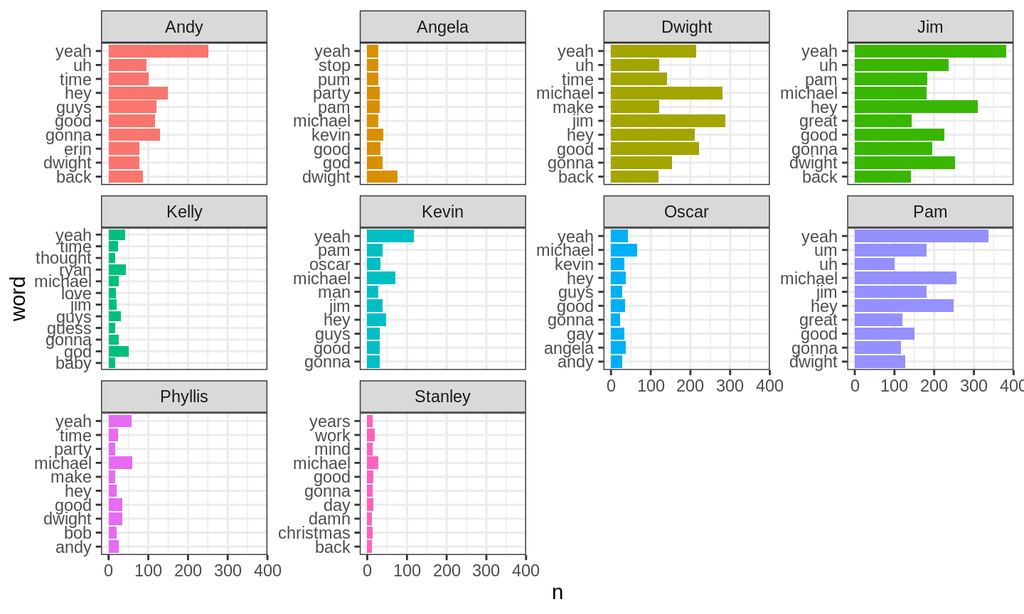

## Tarea 1

- Ver para cada temporada cuales son los 10 personajes con más palabras (cambia en el tiempo?)
- Quien aumenta y quien disminuye mas?
- Crear una columna de delta palabras entre temporadas por personaje por episodio de la serie